# Manipulating RNA-based Therapeutics to increase Treament Efficacy

Fionny Darmawan

06/09/2023

# The Question

How can RNA-based therapeutics be combined with other therapies to enhance their effectiveness?

#### Disclaimer: This project analyzes simulated data. The questions and hypotheses are real, but the results and conclusions are not.

### *Sub-Field of Biology:*

Biotechnology

### *Rationale and Background:*

My background for asking this question is my interest in learning about the advancements that scientists have researched and experimented with RNA molecules, by creating these RNA based therapeutics drugs to modulate gene expression and treat various diseases. After reading some relevant articles below, it seems like they offer the potential to target specific genes and pathways involved in disease processes, providing a more targeted and personalized approach to therapy. RNA based therapies are currently still being developed and experimented, focused on the applications of diseases like cancer and rare genetic diseases. After further looking into this development, it seems like the effectiveness of these RNA based therapeutics are not very stable and can easily be influenced by off target effects and their deliveries as therapeutic drugs. Challenges in deliveries refer to the difficulties in effectively and safely delivering RNA-based therapeutics to their intended target cells or tissues within the body. Off-target effects occur when RNA-based therapeutics interact with unintended targets in the body, leading to unintended biological effects. The rationale behind this question is that we want to optimize the potential these RNA based therapeutics and to overcome their limitations. By combining RNA-based therapeutics with other therapies such as small drug molecules, there is higher potential to improve treatment outcomes by synergistically targeting multiple aspects of a disease. This combination can potentially overcome challenges associated with delivery, off-target effects, and limited efficacy, leading to improved clinical outcomes for patients. By identifying effective combinations and understanding the underlying mechanisms, we can develop more effective treatment strategies that help increase capabilities of RNA-based therapeutics and other therapies. The ongoing research and development of such advancements are expanding the potential for RNA-based therapies to play a significant role in the future treatment and cure of a wide range of diseases.

# Examples of relevant literature

### *Review article title:*

“RNA therapy: rich history, various applications and unlimited future prospects”

#### URL:

https://www.ncbi.nlm.nih.gov/pmc/articles/PMC9016686/

#### Abstract:

RNA therapy refers to the treatment or prevention of diseases using RNA-based molecules. The recent advent of a series of effective messenger RNA-based vaccines in response to the COVID-19 pandemic has reignited research interest in RNA therapy. Based on the accumulated results of long-term research in the field of RNA therapy spanning several decades, therapeutic agents for various diseases are being rapidly developed. These therapeutics tend to target diseases that cannot be treated with other conventional drug groups, and several clinical studies are underway for a variety of RNA-based therapeutics against various incurable diseases. This review describes the history of several important discoveries in RNA biology and their impact on key developments in RNA therapy as well as the advantages of RNA therapy. In addition, it describes the action mechanisms and examples of drugs approved for RNA therapy. Finally, this review discusses methods for RNA drug delivery to target organs and cells. Given that RNA therapy is expected to advance and play an integral role in the development of novel therapeutic agents for human diseases in the future, this review is designed to offer an updated reference point for researchers in this field.

### *Relevant original research article title:*

“A new developing class of gene delivery: messenger RNA-based therapeutics”

#### URL:

https://pubs.rsc.org/en/content/articlehtml/2017/bm/c7bm00712d

#### Abstract:

Gene therapy has long been held as having the potential to become a front line treatment for various genetic disorders. However, the direct delivery of nucleic acids to correct a genetic disorder has numerous limitations owing to the inability of naked nucleic acids (DNA and RNA) to traverse the cell membrane. Recently, messenger RNA (mRNA) based delivery has become a more attractive alternative to DNA due to the relatively easier transfection process, higher efficiency and safety profile. As with all gene therapies, the central challenge that remains is the efficient delivery of nucleic acids intracellularly. This review presents the recent progress in mRNA delivery, focusing on comparing the advantages and limitations of non-viral based delivery vectors.

# **Hypotheses**

### *The Biological Hypothesis:*

Combining RNA-based therapeutics with small molecule drugs that target complementary pathways may lead to synergistic effects, resulting in greater efficacy and reduced off-target effects compared to either therapy alone.

### *The Biological Prediction:*

Combining RNA-based therapeutics with small molecule drugs will lead to greater efficacy compared to either therapy alone. In other words, the combination of RNA-based therapeutics with small molecule drugs results in a more effective cure.

### *A Statistical Alternative Hypothesis:*

The combination of RNA-based therapeutics and small molecule drugs will result in synergistic effects, a greater efficacy in the combination between the two than individually. There will be significant difference in the result.

### *A Statistical Null Hypothesis:*

The combination of RNA-based therapeutics and small molecule drugs will result in no significant difference in terms of their synergistic effects over their individual effects.

# Experimental Design

### *Explanatory and Response Variables:*

The explanatory/independent variable is the type of treatment being given, in this case there are three independent variables: Combination of RNA-based therapies and small drug molecules, RNA-based therapies alone, and small drug molecules alone. The response/dependent variable is the measures of efficacy or their synergistic effects.

### *Alpha:*

My alpha value is 0.05 (5%).Not only this is the standardized alpha value, but also this value would fit best for y experiment as it would show a balance between the two errors of incorrectly rejecting the null hypothesis when it is true, and failing to reject the null hypothesis when it is false.

# Data Analysis Plan

For my analysis, I will use the ANOVA, which determines if there are significant differences in efficacy among the three treatment groups, using the ANOVA test.

I chose to do my analysis with a linear model with 3 categorical levels (ANOVA) to compare the effectiveness of different treatment combinations. This test would also help me determine if there are significant differences in efficacy among the 3 groups. I chose this test instead of regression because I want to have organized controlled groups rather than continuous independent variables of the dosage or concentration of the drugs. Same goes with methods like correlation or chi-squared test. They are more so dosage-dependent and would not really give results of significant difference of categorical levels.

# Assumptions and Exploratory Data Analysis (EDA)

For this experiment, I chose to use a Linear model with 3 categorical levels using the ANOVA test as my data model and primary statistical test. There are some assumptions of my chosen test that I’ve considered.One is independence; the observations within each treatment group should be independent of each other. Another assumption is normality in which the differences between the observed and predicted values should follow a normal distribution. The next assumption is consistency of variances where the variability of the residuals should be consistent across the treatment group. Another assumption is that the variances of efficacy scores within each treatment group are equal. Lastly,the relationship between treatment groups and efficacy is assumed to be linear. In other words, the effect of treatment group on efficacy is consistent across all levels of the independent variable.

```r
#USE THIS BLOCK TO INPUT NECESSARY CODE.
TreatmentData<- read.csv("fdarmawan.csv")

newTreatmentData<- TreatmentData %>%
        select(-X)


tidy_TreatmentData<- pivot_longer(newTreatmentData, everything(), names_to = "TreatmentGroup", values_to = "Efficacy")
#head(tidy_TreatmentData)

mean_value <- mean(tidy_TreatmentData$Efficacy)
sd_value <- sd(tidy_TreatmentData$Efficacy)

threshold <- 2

outliers <- tidy_TreatmentData[tidy_TreatmentData$Efficacy > (mean_value + threshold * sd_value) | tidy_TreatmentData$Efficacy < (mean_value - threshold * sd_value), ]

# Remove outliers from the dataframe
newTidy_TreatmentData <- tidy_TreatmentData[!(tidy_TreatmentData$Efficacy %in% outliers$Efficacy), ]

transformed_TreatmentData<- mutate(newTidy_TreatmentData, log_Efficacy = log(Efficacy))
head(newTidy_TreatmentData)
```

```
## # A tibble: 6 × 2
##   TreatmentGroup                                                  Efficacy
##   <chr>                                                              <dbl>
## 1 Combination.of.RNA.based.therapeutics.and..small.molecule.drugs     38.1
## 2 Small.Molecule.Drugs                                                31.4
## 3 RNA.based.Therapeutics                                              35.0
## 4 Combination.of.RNA.based.therapeutics.and..small.molecule.drugs     51.2
## 5 Small.Molecule.Drugs                                                25.6
## 6 RNA.based.Therapeutics                                              43.7
```

### *Interpretation of EDA:*

In this Experimental Design Analysis, I organized my original data into a tidy data that consists of 2 columns: One represents the independent variables of each treatment group being administered to the participants, and the other one is the dependent variable of the measures of efficacy or their synergistic effects. I organized by data into a tidy data so that it would fit my linear model and allows for testing using the ANOVA. A tidy data allows me to have easy aggregation and summarization of the data by treatment groups. After creating and testing the my data model, it seems like the results that I am getting do not indicate a significant difference in my hypothesis. So I decided to transform my tidy data using log() transform function, so that my analysis follows more of normal distributed model.

# Primary Statistical Analysis

```r
#USE THIS BLOCK TO INPUT NECESSARY CODE.
TreatmentModel<- lm(`log_Efficacy` ~ `TreatmentGroup`, data = transformed_TreatmentData)
summary(TreatmentModel)
```

```
##
## Call:
## lm(formula = log_Efficacy ~ TreatmentGroup, data = transformed_TreatmentData)
##
## Residuals:
##      Min       1Q   Median       3Q      Max
## -0.64583 -0.12556  0.01174  0.13818  0.44377
##
## Coefficients:
##                                      Estimate Std. Error t value Pr(>|t|)
## (Intercept)                           3.86627    0.02002 193.156   <2e-16 ***
## TreatmentGroupRNA.based.Therapeutics -0.19481    0.02838  -6.865    4e-11 ***
## TreatmentGroupSmall.Molecule.Drugs   -0.26891    0.02838  -9.476   <2e-16 ***
## ---
## Signif. codes:  0 '***' 0.001 '**' 0.01 '*' 0.05 '.' 0.1 ' ' 1
##
## Residual standard error: 0.1992 on 292 degrees of freedom
## Multiple R-squared:  0.2473, Adjusted R-squared:  0.2421
## F-statistic: 47.97 on 2 and 292 DF,  p-value: < 2.2e-16
```

```r
TreatmentModelTest<- aov(`log_Efficacy` ~ `TreatmentGroup`, data = transformed_TreatmentData)
summary(TreatmentModelTest)
```

```
##                 Df Sum Sq Mean Sq F value Pr(>F)
## TreatmentGroup   2  3.805  1.9026   47.97 <2e-16 ***
## Residuals      292 11.582  0.0397
## ---
## Signif. codes:  0 '***' 0.001 '**' 0.01 '*' 0.05 '.' 0.1 ' ' 1
```

```r
post_hoc_TreatmentModelTest<- TukeyHSD(TreatmentModelTest)
summary(post_hoc_TreatmentModelTest)
```

```
##                Length Class  Mode
## TreatmentGroup 12     -none- numeric
```

# Data Visualization

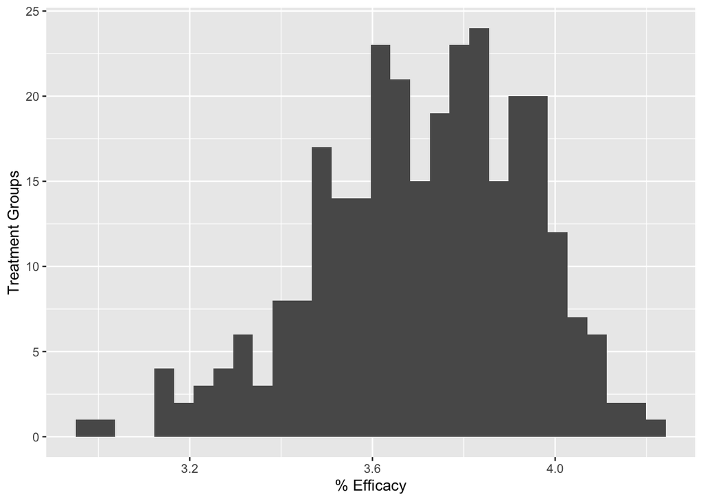

```r
#USE THIS BLOCK TO INPUT NECESSARY CODE.
Treatment_Histogram<- ggplot(transformed_TreatmentData, aes(x = log_Efficacy)) +
                         geom_histogram() +
                        labs(x = "% Efficacy", y = "Treatment Groups")
Treatment_Histogram
```

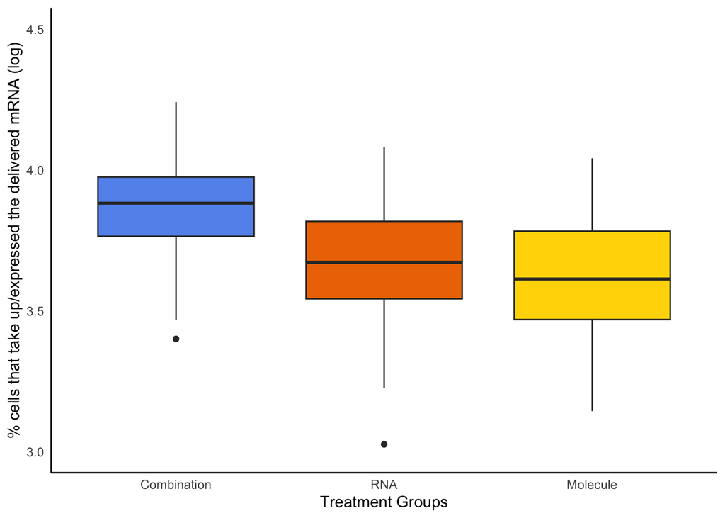

```r
colors <- c("cornflowerblue", "darkorange2", "gold1")

y_lower <- 3
y_upper <- 4.5

Treatment_boxPlot<- ggplot(transformed_TreatmentData, aes(x = TreatmentGroup, y = log_Efficacy)) +
  geom_boxplot(fill = colors) +
  ylim(y_lower, y_upper) +
  labs(x = "Treatment Groups", y = "% cells that take up/expressed the delivered mRNA (log)") +
  theme_minimal() +
  theme(
    panel.grid.major = element_blank(),
    panel.grid.minor = element_blank(),
    panel.border = element_blank(),
    axis.line = element_line(size = 0.5)
  ) +
  scale_x_discrete(labels = c("Combination", "RNA", "Molecule")) +
  scale_fill_manual(values = colors)
Treatment_boxPlot
```

# Conclusions

To reiterate, I used the Linear model with 3 categorical levels (ANOVA), and TukeyHSD() functions to model and test my experiment.

Overall, the results of my experimental design analysis agree with my biological hypothesis and prediction in that the combination of RNA-based therapeutics with small molecule drugs results in a more effective cure.

# Future Directions

A couple of confounding variables that I did not include were the severity of the disease for each participant in each treatment group, and the characteristics of these participants. In this experimental design I did not stratify participants based on disease severity, which could have affected a bias in the efficacy results. In other words, the responses of the treatments could be misleading and bias due to an unfair level of the disease severity in each group. In this experiment I also did not consider the characteristics of the participants such as their age, gender, and their genetic profile. This confounding variable could also have the same effect as my first confounding variable in which the responses of these treatments would not be as consistent or even across each subgroup of treatment.

If there were no restrictions placed on my design, I would probably increase my sample size, as a larger sample size can provide more reliable and precise estimates of treatment effects. I would also include a control group that receives a placebo or standard treatment in addition to the three control groups. This would allow for a better comparison and assessment of the specific treatment effects. I would also explore different doses and durations of the treatments to find potential dose-response relationships and optimal treatment procedures. This can provide insights into the therapeutic efficacy and help identify the most effective treatment approach. Then I would try to use advanced statistical techniques beyond ANOVA to further analyze the data, as well as seek advising and collaboration with other experts to study my experiment.

# Citations

Experimental Design - University of Central Arkansas — UCA, uca.edu/psychology/files/2013/08/Ch10-Experimental-Design_Statistical-Analysis-of-Data.pdf. Accessed 11 June 2023.

“Experimental Design.” Statistics How To, 7 Feb. 2023, www.statisticshowto.com/experimental-design/.